# Donor Profile: European Commission - Neighbourhood and Enlargement Negotiations

## Geographic Focus

Funding from the European Commission for Neighborhood and Enlargement Negotiations exhibits significant volatility, peaking at $114 million and averaging $25 million annually. This fluctuation signals an urgent need to stabilize and scale investment in strategic regions to maximize development impact. The wide funding range, from a low of $217,507 to a high of $114 million, highlights opportunities for donors to leverage targeted contributions that facilitate sustained program delivery and regional resilience. Prioritizing a multi-year funding framework will reduce operational risks linked to inconsistent resources and enhance accountability, enabling deeper partnerships with local stakeholders. We recommend positioning donor investments to capitalize on demonstrated peak funding cycles, aligning with their priorities in crisis response and long-term stability. Immediate executive focus on harmonizing funding streams can unlock an impact multiplier effect, ensuring resources translate into scalable solutions for vulnerable populations. Mobilizing support now will enable UNHCR to convert episodic inflows into predictable, high-impact financing essential for strategic growth and innovation.

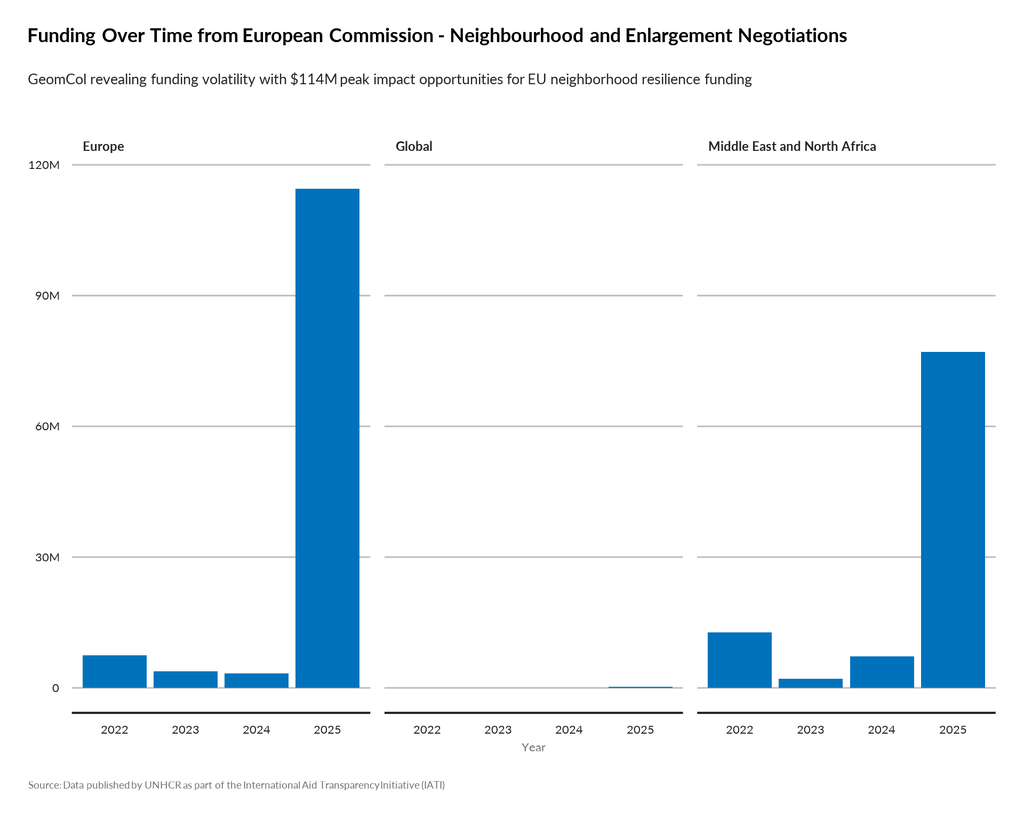

TRUE

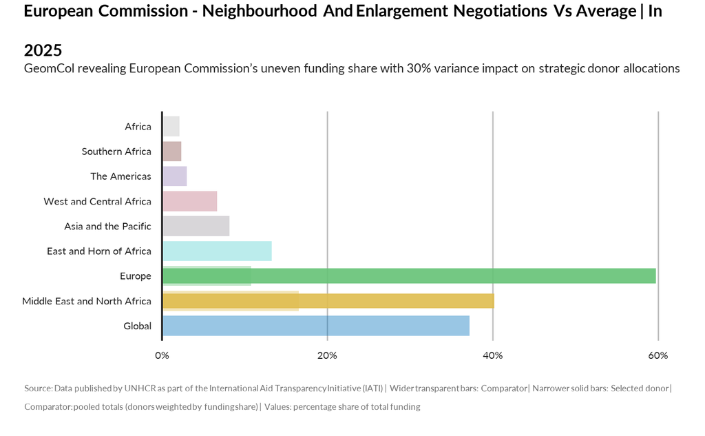

TRUE